# 🏎️ Nina's F1 Predictions: 2026 Austria Grand Prix (Round 8)

## Red Bull Ring — June 26-28, 2026

**Model version:** v1.0+Q (early weekend, pre-qualifying) **Confidence:** MEDIUM — grid is estimated, not yet set

### What This Is

A machine learning model that predicts Formula 1 race results from 24 features — the same kinds of data a race engineer considers when building race strategy. This is the **first cut of the weekend**, made before qualifying: the model trains on every race so far this season (2026 weighted 10x over 2023-2025 history) and estimates the grid from team pace plus driver form. It refreshes as practice and qualifying data arrive — the qualifying update is the biggest jump in accuracy.

> **The grid here is an estimate, so treat this as a baseline.** It will be replaced by the real qualifying result, and the race accuracy check added, as the weekend progresses.

```
============================================================
  🤖 XGBOOST v1.0 — 24 features, trained through Round 7
============================================================
  Training rows: 1,551
  Leave-one-out MAE: 2.27 positions (honest)
  Residual StdDev:   2.92

  Top features:
    grid_position             0.227
    team_pit_strategy         0.083
    sector2_delta             0.076
    team_changed              0.065
    car_speed                 0.061
    car_pace                  0.061
    sector3_delta             0.046
    driver_avg_finish         0.044
```

## 1. Season Pace & Estimated Grid

Qualifying hasn't run yet, so there is no real grid. The model estimates the starting order from team pace (season form blended with any practice that has run) plus each driver's season form, and uses Austria's historical sector profile. **The grid below is an estimate** — it will be replaced by the real qualifying result when this page is regenerated on Saturday, which is the single biggest accuracy jump of the weekend.

```
  🌤️ Forecast (Open-Meteo, 2026-06-28): 34°C, 35% RH, 20% rain
```

```
======================================================================
  📊 ESTIMATED GRID — 2026 Austria GP  [stage: post-FP2]
======================================================================

  Est  Driver                  Team                Blend Pace
  ------------------------------------------------------------
  P 1  Kimi Antonelli          Mercedes            P   3.3
  P 2  George Russell          Mercedes            P   3.3
  P 3  Lewis Hamilton          Ferrari             P   6.3
  P 4  Oscar Piastri           McLaren             P   4.6
  P 5  Lando Norris            McLaren             P   4.6
  P 6  Charles Leclerc         Ferrari             P   6.3
  P 7  Max Verstappen          Red Bull Racing     P   7.5
  P 8  Isack Hadjar            Red Bull Racing     P   7.5
  P 9  Liam Lawson             Racing Bulls        P  10.0
  P10  Arvid Lindblad          Racing Bulls        P  10.0
  P11  Pierre Gasly            Alpine              P  11.9
  P12  Franco Colapinto        Alpine              P  11.9
  P13  Gabriel Bortoleto       Audi                P  12.9
  P14  Nico Hulkenberg         Audi                P  12.9
  P15  Esteban Ocon            Haas F1 Team        P  14.6
  P16  Oliver Bearman          Haas F1 Team        P  14.6
  P17  Carlos Sainz            Williams            P  16.4
  P18  Alexander Albon         Williams            P  16.4
  P19  Sergio Perez            Cadillac            P  19.5
  P20  Fernando Alonso         Aston Martin        P  19.5
  P21  Valtteri Bottas         Cadillac            P  19.5
  P22  Lance Stroll            Aston Martin        P  19.5

  Grid is ESTIMATED from pace + form; real qualifying replaces it Saturday.

  🌡️ Race conditions: 33.8°C, 35% humidity, 20% rain -> DRY
  Predictions are a 20% wet / 80% dry blend.
```

## 2. Predicted Finish

```
================================================================================
  🏁 PREDICTED FINISH — 2026 Austria GP
================================================================================

  Pos  Driver                  Team                Grid   Pred  ΔGrid
  ----------------------------------------------------------------------
  P 1  Lewis Hamilton          Ferrari             P 3  P 4.0     +2
  P 2  Lando Norris            McLaren             P 5  P 4.6     +3
  P 3  Charles Leclerc         Ferrari             P 6  P 4.8     +3
  P 4  Kimi Antonelli          Mercedes            P 1  P 4.9     -3
  P 5  Oscar Piastri           McLaren             P 4  P 5.1     -1
  P 6  Max Verstappen          Red Bull Racing     P 7  P 5.2     +1
  P 7  George Russell          Mercedes            P 2  P 5.5     -5
  P 8  Isack Hadjar            Red Bull Racing     P 8  P 8.4      =
  P 9  Liam Lawson             Racing Bulls        P 9  P 9.7      =
  P10  Arvid Lindblad          Racing Bulls        P10  P10.3      =
  P11  Pierre Gasly            Alpine              P11  P10.6      =
  P12  Franco Colapinto        Alpine              P12  P11.8      =
  P13  Oliver Bearman          Haas F1 Team        P16  P12.5     +3
  P14  Gabriel Bortoleto       Audi                P13  P12.8     -1
  P15  Esteban Ocon            Haas F1 Team        P15  P13.2      =
  P16  Nico Hulkenberg         Audi                P14  P13.4     -2
  P17  Carlos Sainz            Williams            P17  P15.0      =
  P18  Fernando Alonso         Aston Martin        P20  P15.1     +2
  P19  Lance Stroll            Aston Martin        P22  P15.3     +3
  P20  Sergio Perez            Cadillac            P19  P15.7     -1
  P21  Valtteri Bottas         Cadillac            P21  P17.4      =
  P22  Alexander Albon         Williams            P18  P18.4     -4
```

## 3. Podium Probabilities (10,000 Simulated Races)

Rather than a single outcome, the model simulates the race 10,000 times with realistic randomness — and now models **retirements**: each driver can DNF with their season failure rate, which promotes everyone behind them. That matters most at high-attrition tracks, where a front-runner's mechanical failure reshuffles the order. Add a 33% safety-car chance and grid-dependent chaos (the midfield is messier than the front row), and the result is a probability for each driver.

```
  Modeled retirements: 4.6 per race (driven by each driver's season DNF rate)

================================================================================
  🎲 PODIUM PROBABILITIES — 2026 Austria GP
================================================================================

  Driver                  Team                Grid     Win   Podium    Top5
  ------------------------------------------------------------------------
  Lewis Hamilton          Ferrari             P 3   20.1%    54.2%   76.5%  ██████████
  Charles Leclerc         Ferrari             P 6   17.0%    41.5%   60.1%  ████████
  Kimi Antonelli          Mercedes            P 1   12.6%    45.3%   75.4%  ██████
  Max Verstappen          Red Bull Racing     P 7   12.4%    34.8%   55.1%  ██████
  Lando Norris            McLaren             P 5   12.0%    30.0%   44.8%  ██████
  Oscar Piastri           McLaren             P 4   10.6%    29.6%   47.3%  █████
  George Russell          Mercedes            P 2    6.6%    31.2%   59.5%  ███
  Isack Hadjar            Red Bull Racing     P 8    3.5%    10.9%   20.9%  █
  Liam Lawson             Racing Bulls        P 9    2.1%     7.4%   17.1%  █
  Arvid Lindblad          Racing Bulls        P10    1.3%     5.2%   12.7%
  Pierre Gasly            Alpine              P11    0.9%     4.4%   11.5%
  Franco Colapinto        Alpine              P12    0.6%     2.6%    7.6%
```

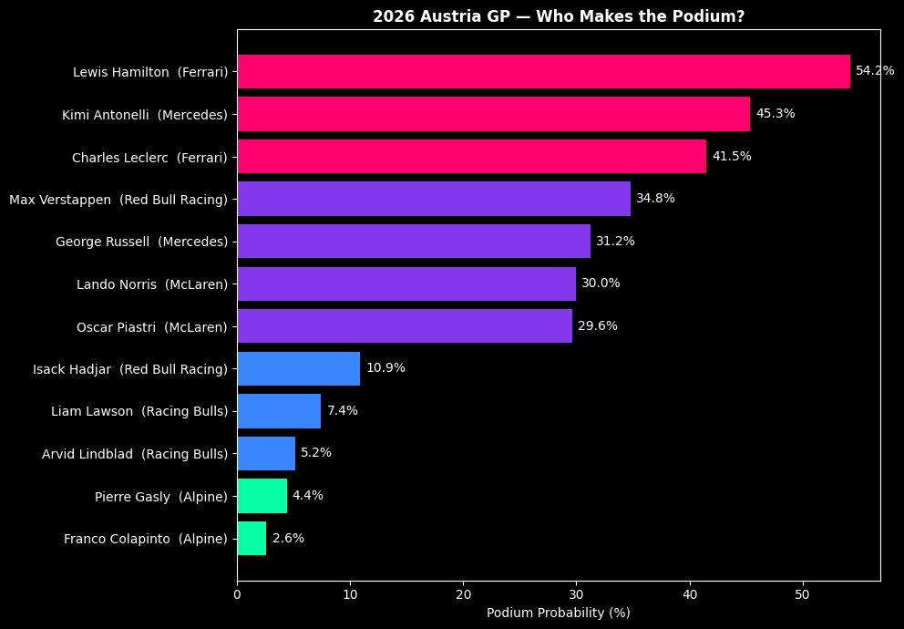

## 4. What Happens Next

*This is the pre-qualifying baseline for the Austria GP. It refreshes through the weekend:*

- *Friday (after practice): rerun `--pre-qualifying` to fold in FP pace.*
- *Saturday (after qualifying): rerun `--pre-race --weather auto` for the real grid — the biggest accuracy jump.*
- *After the race: run `update_data.py` then rerun with no flag to add the official results and accuracy.*